# The accuracy of using van Wagtendonk (1996) woody fuel average diameters to estimate fuel load levels in mixed conifer forests in the Sierra Nevada

Natalie Coy

12/14/2020

## Pilot Study Summary

[output not shown]

## Background

[output not shown]

## Senior Thesis Research Questions

```
This study will use actual fine woody debris diameters and estimated fine woody debris diameters to investigate van Wagtendonk's approach and address the following questions:

How accurate is the van Wagtendonk (1996) approach for estimating fuel loads from forest composition in mixed conifer forest in the Sierra Nevada?
1. What is the forest composition of our site and the actual FWD diameter measurements?
2. What are the estimated FWD diameters from using van Wagtendonk’s (1996) approach and how do these compare to our actual measurements?
3. What is the best model for estimating fuel loads from forest composition in a mixed conifer forest?

**As mentioned previously, this pilot study only investigates the first two subquestions.
```

## Pilot Study Results

[output not shown]

Table 1. Species prevalence broken up by plot level

| Comp | Plot | ABCO | CADE | Other | PILA | PIPO | PSME | SEGI |
| --- | --- | --- | --- | --- | --- | --- | --- | --- |
| A | A-001 | 0.000 | 0.449 | 0.090 | 0.000 | 0.000 | 0.461 | 0.000 |
| A | A-003 | 0.187 | 0.455 | 0.074 | 0.000 | 0.209 | 0.075 | 0.000 |
| A | A-005 | 0.097 | 0.429 | 0.094 | 0.000 | 0.208 | 0.172 | 0.000 |
| A | A-020 | 0.264 | 0.326 | 0.160 | 0.000 | 0.080 | 0.170 | 0.000 |
| A | A-023 | 0.206 | 0.456 | 0.102 | 0.000 | 0.000 | 0.236 | 0.000 |
| A | A-024 | 0.410 | 0.354 | 0.155 | 0.000 | 0.000 | 0.081 | 0.000 |
| A | A-025 | 0.000 | 0.287 | 0.290 | 0.000 | 0.079 | 0.344 | 0.000 |
| A | A-028 | 0.111 | 0.381 | 0.019 | 0.023 | 0.141 | 0.326 | 0.000 |
| B | B-008 | 0.249 | 0.132 | 0.000 | 0.344 | 0.119 | 0.155 | 0.000 |
| B | B-010 | 0.000 | 0.262 | 0.102 | 0.180 | 0.290 | 0.166 | 0.000 |
| B | B-013 | 0.170 | 0.306 | 0.053 | 0.000 | 0.000 | 0.471 | 0.000 |
| B | B-016 | 0.071 | 0.551 | 0.178 | 0.000 | 0.000 | 0.200 | 0.000 |
| B | B-026 | 0.039 | 0.173 | 0.231 | 0.000 | 0.363 | 0.058 | 0.137 |
| C | C-010 | 0.153 | 0.469 | 0.000 | 0.000 | 0.152 | 0.225 | 0.000 |
| C | C-011 | 0.053 | 0.536 | 0.000 | 0.000 | 0.115 | 0.296 | 0.000 |
| C | C-022 | 0.308 | 0.227 | 0.186 | 0.096 | 0.111 | 0.073 | 0.000 |
| C | C-025 | 0.266 | 0.340 | 0.000 | 0.055 | 0.230 | 0.110 | 0.000 |
| C | C-026 | 0.335 | 0.507 | 0.000 | 0.000 | 0.105 | 0.053 | 0.000 |

[output not shown]

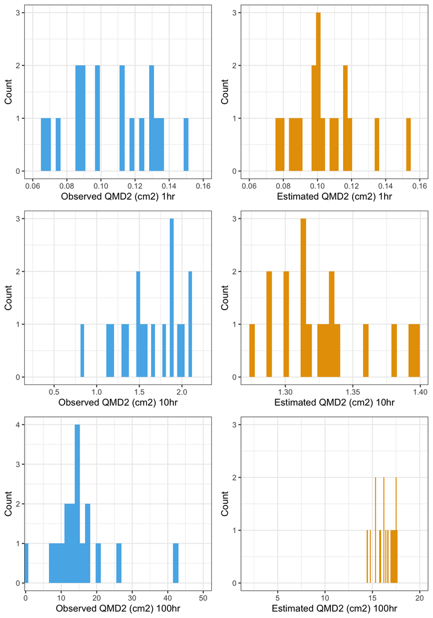

Figure 1. Histograms of Measured and Estimated QMD2

[output not shown]

Table 2. Statistical results from linear regression models for each fuel time-lag class

| Estimated QMD2 | Estimate | Std. Error | Statistic | P value |
| --- | --- | --- | --- | --- |
| 1hr | 1.0042 | 0.0478 | 20.9983 | 0.0000 |
| 10hr | 1.2154 | 0.0674 | 18.0217 | 0.0000 |
| 100hr_intercept | 7.6734 | 35.8375 | 0.2141 | 0.8332 |
| 100hr | 0.4673 | 2.1785 | 0.2145 | 0.8329 |

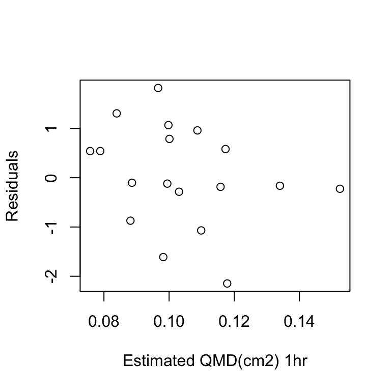

Figure 2A. Residuals for 1 hour fuels

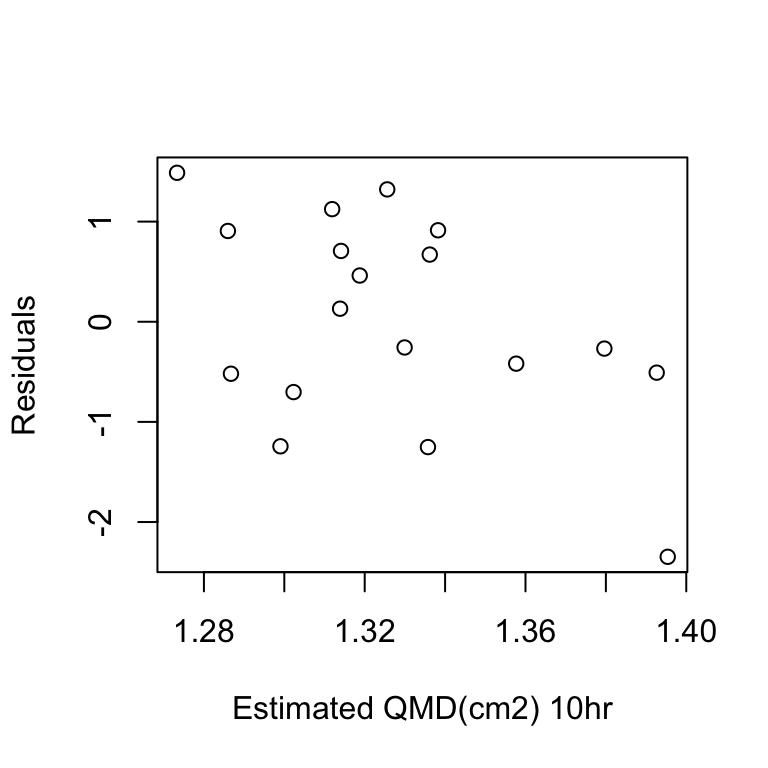

Figure 2B. Residuals for 10 hour fuels

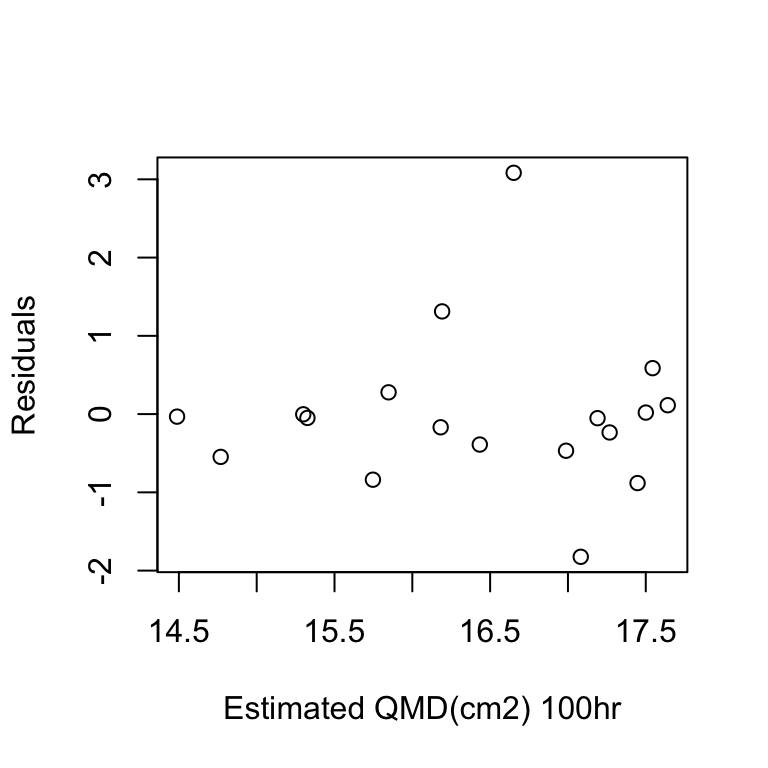

Figure 2C. Residuals for 100 hour fuels

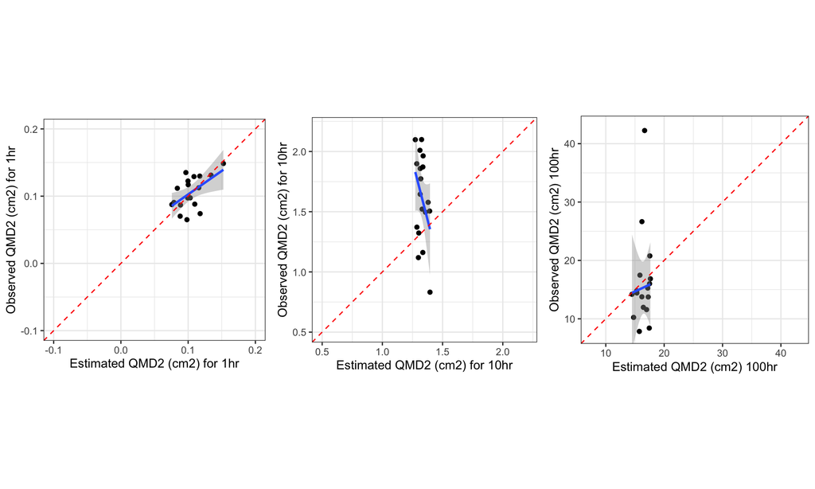

Figure 3. Linear relationship between estimated QMD2 (cm2) and measured QMD2 (cm2). From left to right; 1 hour fuel loads, 10 hour fuel loads and 100 hour fuel loads. The blue line represents the linear regression model for each time-lag class and the red dashed line represents a positive linear regression model.

## Implications of Pilot Study

[output not shown]

## References

Agee, J.K., B. Bahro, M. A. Finney, P. N. Omi, D. B. Sapsis, C. N. Skinner, J.W. van Wagtendonk, and C. P. Weatherspoon. 2000. The use of shaded fuel breaks in landscape fire management. Forest Ecology and Management 127: 55–66.

Brown, J.K. 1974. Handbook for inventorying downed woody material. Gen. Tech. Rep. INT-16. Ogden, UT: U.S. Department of Agriculture, Forest Service, Intermountain Forest Range and Range Experiment Station. 24 p.

Keane, R. E., K. Gray and V. Bacciu. 2012. Spatial variability of wildland fuel characteristics in northern Rocky Mountain ecosystems. Res. Pap. RMRS-RP-98. Fort Collins, CO: U. S. Department of Agriculture, Forest Service, Rocky Mountain Research Station. 56 p.

Keeley, J. E. and A. D. Syphard. 2019. Twenty-first century California, USA, wildfires: fuel-dominated vs wind-dominated fires. Fire Ecology 15.

Stephen, S. L., and B. M. Collin. 2004. Fire regimes of mixed conifer forest in the north-central Sierra Nevada at multiple spatial scales. Northeast Science 78: 12-23.

Stephens, S. L., S. J. Husari, H. T. Nichols, N. G. Sugihara, and B. M. Collins. 2018. Fire and Fuel Management. Fire in California’s Ecosystems: 411-428.

van Wagtendonk, J., J. M. Benedict, and W. M. Sydoriak. 1996. Physical properties of woody fuel particles of Sierra Nevada conifers. International Journal of Wildland Fire 6(3): 117-123.